# Colonial v. Solitary Phaeocystis Gene Espression

Maggi Brisbin

May 7, 2018

Load Packages

```r
library("DESeq2") # Differential expression analysis suite
```

```r
library("ggplot2") # Plotting
library("genefilter") # Filtering genes from high-throughput experiments
library("gplots") # Plotting
library("BiocParallel") # multicore distribution
library("pheatmap") # Plotting
library("stringi")
library("edgeR")
library(GOstats)
library("GSEABase")
library(tidyr)
library( scales )
library(ggrepel)
library("shiny")
library(plotly)
library("wesanderson")
library(clusterProfiler)
library(DOSE)
```

# 1 Load and Prepare Data

Data is RSEM output when aligning to longest isoform from Eukaryote Only Trinity assembly

```r
`C1.genes` <- read.delim("C1.genes.results")
`C2.genes` <- read.delim("C2.genes.results")
`C3.genes` <- read.delim("C3.genes.results")
`C4.genes` <- read.delim("C4.genes.results")
`S1.genes` <- read.delim("S1.genes.results")
`S2.genes` <- read.delim("S2.genes.results")
`S3.genes` <- read.delim("S3.genes.results")
`S4.genes` <- read.delim("S4.genes.results")
```

Trinity Assembly has 69,528 “genes”

Make a data frame with the geneID and FPKM from each sample

```r
FPKM<- data.frame(C1.genes$gene_id,C1.genes$FPKM,C2.genes$FPKM,C3.genes$FPKM,C4.genes$FPKM,S1.genes$FPKM,S2.genes$FPKM,S3.genes$FPKM,S4.genes$FPKM)
names(FPKM)<-c("gene_id","C1","C2","C3", "C4","S1","S2","S3", "S4")
```

Remove rows without at least one sample with FPKM >= 1

```r
row.names(FPKM)<- FPKM[[1]]
FPKM<- FPKM[,(-1)]
FPKM<-FPKM[apply(FPKM>=1,1,any),]
```

54,737 genes remaining

Make a data frame with the geneID and the expected counts column from each sample

```r
Genes<- data.frame(C1.genes$gene_id,C1.genes$expected_count,C2.genes$expected_count,C3.genes$expected_count,C4.genes$expected_count, S1.genes$expected_count,S2.genes$expected_count,S3.genes$expected_count,S4.genes$expected_count)
names(Genes)<-c("gene_id", "C1","C2","C3", "C4","S1","S2","S3", "S4")
```

Filter counts data frame to hold only the genes with >1 FPKM

```r
Genes <- Genes[Genes$gene_id %in% row.names(FPKM),]
```

prepare matrices for DeSeq2

```r
counts <- Genes[,2:9]
counts <- sapply(counts, as.integer)
rownames(counts)<-Genes[ , 1] #gene names
sampleName<-colnames(counts)
phenotype<- c(rep("colonial",4), rep("solitary",4))
replicate<- c(rep(1:4,2))
sampleTable <-data.frame(row.names=sampleName, phenotype=phenotype, replicate=replicate)
```

Convert matrix to DeSeq2 object

```r
dds <- DESeqDataSetFromMatrix(countData = counts, colData = sampleTable, design = ~ phenotype)
# Remove empty counts
dds <- dds[ rowSums(counts(dds)) > 1, ]
# Count data transformations
rld <- rlog(dds, blind=TRUE)
```

# 2 Data Exploration

## 2.1 Scatterplot

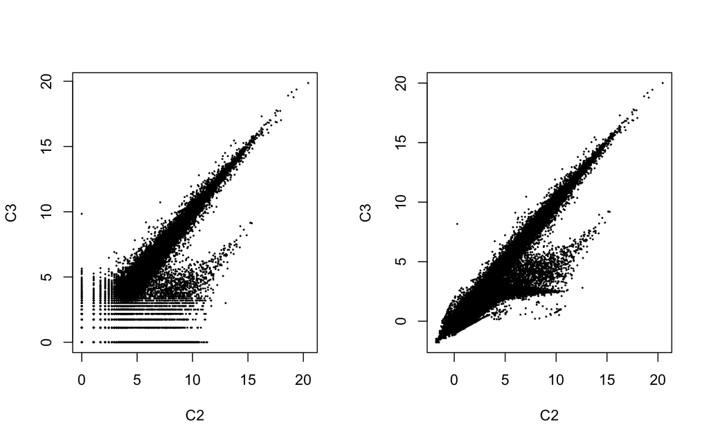

```r
par( mfrow = c( 1, 2 ) )
dds <- estimateSizeFactors(dds)
plot(log2(counts(dds, normalized=TRUE)[,2:3] + 1), pch=16, cex=0.3)
plot(assay(rld)[,2:3], pch=16, cex=0.3)
```

```r
par( mfrow = c( 1, 1 ) )
```

## 2.2 PCA

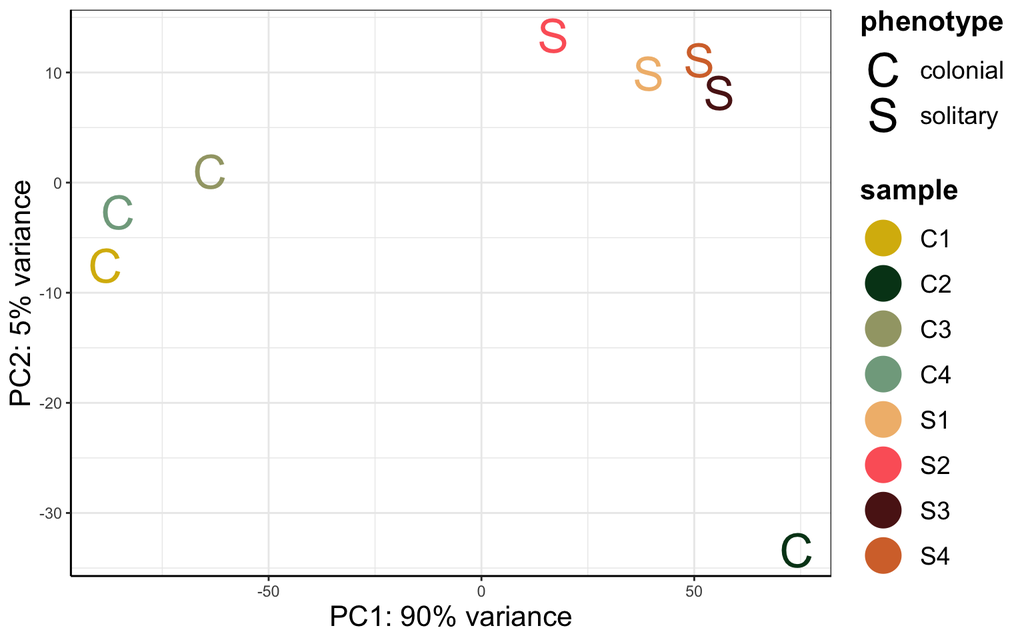

```r
data1 <- plotPCA(rld, intgroup=c("phenotype"), returnData=TRUE)
data1$group<-gsub(" : ","_",as.character(data1$group))
percentVar1 <- round(100 * attr(data1, "percentVar"))
wp1<- wes_palette("Cavalcanti1")
wp2<- wes_palette("GrandBudapest1")

PCA<-ggplot(data1, aes(PC1, PC2, group=factor(group), color= name, shape= factor(phenotype)))+
  geom_point(size=9) +scale_shape_manual(
    name="phenotype", values=c("C", "S"))+
  scale_colour_manual(
    name="sample", values= c(wp1[1:4], wp2[1:4])) +
  xlab(paste0("PC1: ",percentVar1[1],"% variance")) +
  ylab(paste0("PC2: ",percentVar1[2],"% variance")) +
  theme_bw() +
  theme(axis.line = element_line(colour = "black"),
        panel.background = element_blank()) + theme(axis.title = element_text(size = 16),
    legend.title=element_text(size=16, face = "bold"),
    legend.text=element_text(size=14))
PCA
```

```r
#ggsave("PCA.png", device="png")
```

*C2 is an outlier, remove this sample.* But, first … ## DE analysis WITH outlier Differential Expression Testing

```r
dds <- DESeq(dds)
```

```
## -- note: fitType='parametric', but the dispersion trend was not well captured by the
##    function: y = a/x + b, and a local regression fit was automatically substituted.
##    specify fitType='local' or 'mean' to avoid this message next time.
```

summarize results

```r
res<- results(dds, contrast=c("phenotype", "colonial", "solitary"))
res05<- results(dds, contrast=c("phenotype", "colonial", "solitary"), alpha=0.05)
summary(res)
```

```
##
## out of 47795 with nonzero total read count
## adjusted p-value < 0.1
## LFC > 0 (up)       : 519, 1.1%
## LFC < 0 (down)     : 306, 0.64%
## outliers [1]       : 2120, 4.4%
## low counts [2]     : 14826, 31%
## (mean count < 2)
## [1] see 'cooksCutoff' argument of ?results
## [2] see 'independentFiltering' argument of ?results
```

```r
summary(res05)
```

```
##
## out of 47795 with nonzero total read count
## adjusted p-value < 0.05
## LFC > 0 (up)       : 385, 0.81%
## LFC < 0 (down)     : 219, 0.46%
## outliers [1]       : 2120, 4.4%
## low counts [2]     : 18532, 39%
## (mean count < 3)
## [1] see 'cooksCutoff' argument of ?results
## [2] see 'independentFiltering' argument of ?results
```

HeatPlot

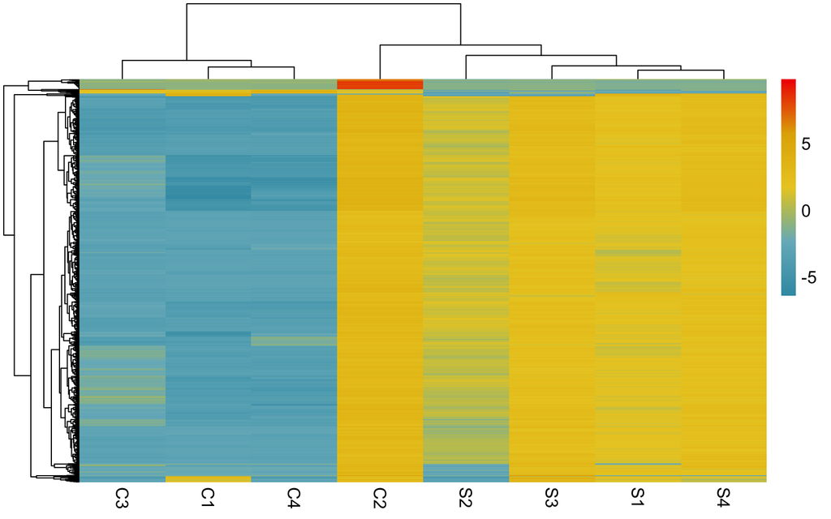

```r
pal <- wes_palette(name = "Zissou1", n=2000 , type= "continuous")
topVarGenes <- head(order(rowVars(assay(rld)),decreasing=TRUE), 1000)
mat <- assay(rld)[ topVarGenes, ]
mat <- mat - rowMeans(mat)
df <- as.data.frame(colData(rld)[,c("phenotype", "replicate")])
labels_row <- c(rep("", 10000))
pheatmap(mat, labels_row = labels_row, fontsize = 12, color = pal)
```

*C2 is not very similar to the rest of the colonial replicates or the solitary replicates*

### 2.2.1 Remove Outlier

```r
Genes<- Genes[,-(3)]
counts <- Genes[,2:8]
counts <- sapply(counts, as.integer)
rownames(counts)<-Genes$gene_id #gene names
sampleName<-colnames(counts)
phenotype<- c(rep("colonial",3), rep("solitary",4))
replicate<- c(1:3, 1:4)
sampleTable <-data.frame(row.names=sampleName, phenotype=phenotype, replicate=replicate)
dds <- DESeqDataSetFromMatrix(countData = counts, colData = sampleTable, design = ~ phenotype)
dds <- dds[ rowSums(counts(dds)) > 1, ]
rld <- rlog(dds, blind=TRUE)
```

```
## -- note: fitType='parametric', but the dispersion trend was not well captured by the
##    function: y = a/x + b, and a local regression fit was automatically substituted.
##    specify fitType='local' or 'mean' to avoid this message next time.
```

### 2.2.2 Scatterplot w/out Outlier

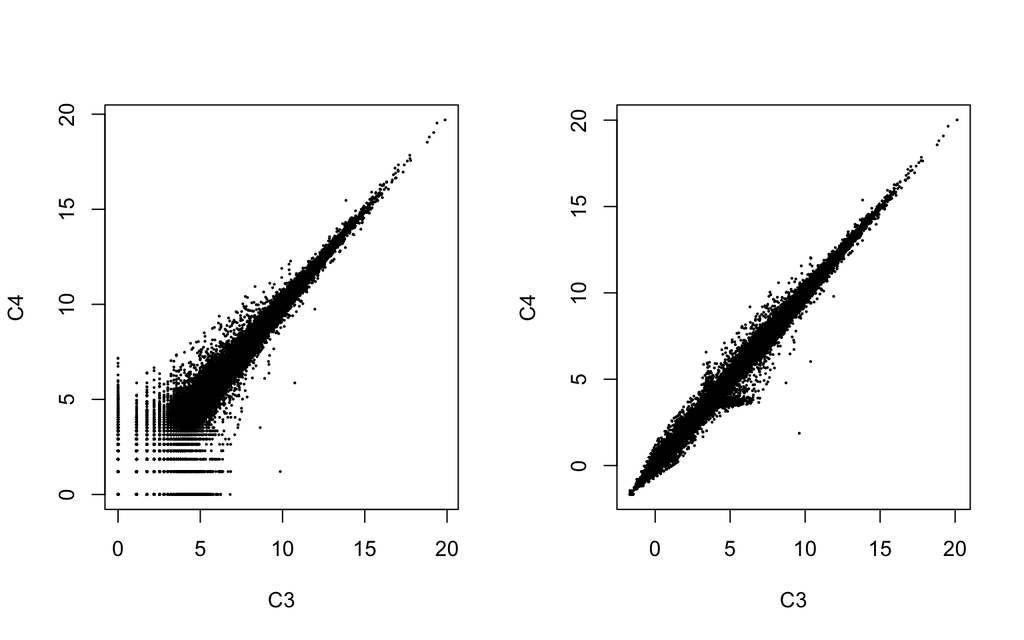

```r
par( mfrow = c( 1, 2 ) )
dds <- estimateSizeFactors(dds)
plot(log2(counts(dds, normalized=TRUE)[,2:3] + 1), pch=16, cex=0.3)
plot(assay(rld)[,2:3], pch=16, cex=0.3)
```

```r
par( mfrow = c( 1, 1 ) )
```

**single-line** after outlier removal

### 2.2.3 PCA w/out Outlier

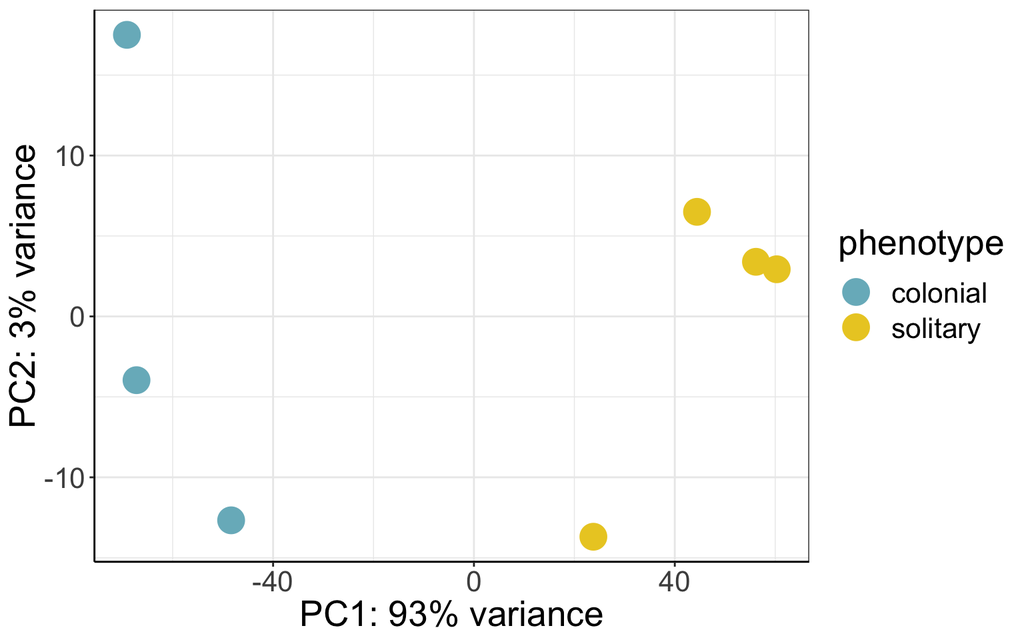

```r
data1 <- plotPCA(rld, intgroup=c("phenotype"), returnData=TRUE)
data1$group<-gsub(" : ","_",as.character(data1$group))
percentVar1 <- round(100 * attr(data1, "percentVar"))

pal<-wes_palette(name = "Zissou1", type="discrete")


pca <- ggplot(data1, aes(PC1, PC2, group=factor(group), color= factor(group), shape=factor(group))) +
  geom_point(size=7) +
  scale_shape_manual(
    name="phenotype",
    values=c(rep(16,2),rep(17,2)) ) +
  scale_colour_manual(
    name="phenotype",
    values=rep(c(pal[2],pal[3]),4) ) +
  xlab(paste0("PC1: ",percentVar1[1],"% variance")) +
  ylab(paste0("PC2: ",percentVar1[2],"% variance")) +
  theme_bw() +
  theme(axis.line = element_line(colour = "black"),
        panel.background = element_blank()) +
  theme(text = element_text(size=20))

pca
```

```r
#ggsave("pca.pdf", width = 8, height = 5, units = "in")
```

# 3 Differential Expression Testing

```r
dea <- DESeq(dds)
```

summarize results

```r
res<- results(dea, contrast=c("phenotype", "colonial", "solitary"), alpha=0.05)
summary(res)
```

```
##
## out of 43301 with nonzero total read count
## adjusted p-value < 0.05
## LFC > 0 (up)       : 535, 1.2%
## LFC < 0 (down)     : 7234, 17%
## outliers [1]       : 124, 0.29%
## low counts [2]     : 14272, 33%
## (mean count < 3)
## [1] see 'cooksCutoff' argument of ?results
## [2] see 'independentFiltering' argument of ?results
```

```r
head(res, n=2)
```

```
## log2 fold change (MLE): phenotype colonial vs solitary
## Wald test p-value: phenotype colonial vs solitary
## DataFrame with 2 rows and 6 columns
##                                    baseMean     log2FoldChange
##                                   <numeric>          <numeric>
## TRINITY_DN100000_c0_g1_i1  0.17876064213371 -0.602600008002843
## TRINITY_DN100003_c0_g1_i1 0.289876169145497  -0.93054225059177
##                                      lfcSE               stat
##                                  <numeric>          <numeric>
## TRINITY_DN100000_c0_g1_i1 3.81115178992784 -0.158114932497677
## TRINITY_DN100003_c0_g1_i1 3.79708288010882 -0.245067669043111
##                                      pvalue      padj
##                                   <numeric> <numeric>
## TRINITY_DN100000_c0_g1_i1 0.874366234193678        NA
## TRINITY_DN100003_c0_g1_i1 0.806404036070786        NA
```

colonial was compared to solitary  
(+) is upregulated in colonial cultures and (-) is downregulated in colonial cultures

## 3.1 MA Plot

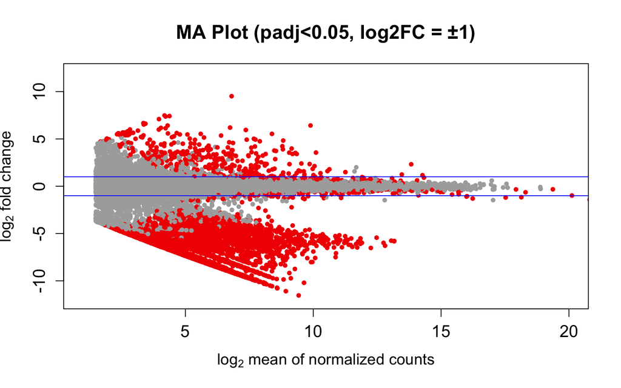

```r
resLFC <- lfcShrink(dea, contrast=c("phenotype", "colonial", "solitary"), alpha=0.05)
#png(filename = "MAplot.png", width = 8.44, height = 6.67, units = "in", res = 720)
plot(log2(resLFC$baseMean), resLFC$log2FoldChange, col=ifelse(resLFC$padj < 0.05, "#F21A00","gray67"),main="MA Plot (padj<0.05, log2FC = ±1)",xlim=c(1,20),pch=20,cex=1,ylim=c(-12,12), ylab=expression(paste('log'[2], ' fold change')), xlab=expression(paste('log'[2]," mean of normalized counts")), cex.lab=1.2, cex.axis=1.3, cex.main=1.5)
abline(h=c(-1,1), col="blue")
```

```r
#dev.off()
```

How many genes are significantly differentially expressed at p<0.05? Use padj (not p). `padj` is the p value adjusted for multiple comparisons using the Benjamini-Hochberg adjustment, which takes into account false discovery rate (FDR).

```r
sum(res$padj < 0.05, na.rm=TRUE)
```

```
## [1] 7769
```

## 3.2 Heatmap

```r
topVarGenes <- head(order(rowVars(assay(rld)),decreasing=TRUE), 1000)
mat <- assay(rld)[ topVarGenes, ]
mat <- mat - rowMeans(mat)
df <- as.data.frame(colData(rld)[,c("phenotype", "replicate")])
labels_row <- c(rep("", 10000))
```

`rlog` stands for regularized log and produces " transformed data on the log2 scale which has been normalized with respect to library size or other normalization factors"

`assay(rld)` function extracts the matrix of normalized values

The following is a heat map of the difference in transformed count for each sample from the mean transformed count for the “gene” across all samples:

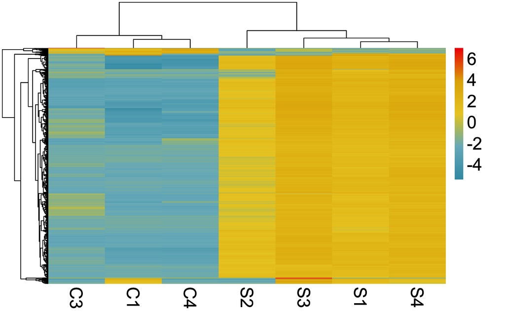

```r
#pdf(file= "pheat.pdf")
pal <- wes_palette(name = "Zissou1", n=2000 , type= "continuous")
heat <- pheatmap(mat, labels_row = labels_row, fontsize = 20, color = pal)
heat
```

```r
#dev.off()
```

# 4 DSYB and Alma plots

```r
goi <- c("TRINITY_DN85929_c2_g1_i4", "TRINITY_DN67928_c0_g2_i2", "TRINITY_DN51587_c0_g1_i1" , "TRINITY_DN90393_c0_g1_i4")
stopifnot(all(goi %in% names(dea)))
goi
```

```
## [1] "TRINITY_DN85929_c2_g1_i4" "TRINITY_DN67928_c0_g2_i2"
## [3] "TRINITY_DN51587_c0_g1_i1" "TRINITY_DN90393_c0_g1_i4"
```

```r
tcounts <- t(log2((counts(dea[goi, ], normalized=TRUE, replaced=FALSE)+.5))) %>%
  merge(colData(dea), ., by="row.names") %>%
  gather(gene, expression, (ncol(.)-length(goi)+1):ncol(.))

annots<-c(rep("P. parvum DSYB-like", 7), rep("P. fradulenta DSYB-like", 7), rep("Alma7-like", 7), rep("Alma4-like", 7))

tcounts$annots <- annots
tcounts$annots_f = factor(tcounts$annots, levels=c("P. parvum DSYB-like","P. fradulenta DSYB-like","Alma4-like","Alma7-like"))
```

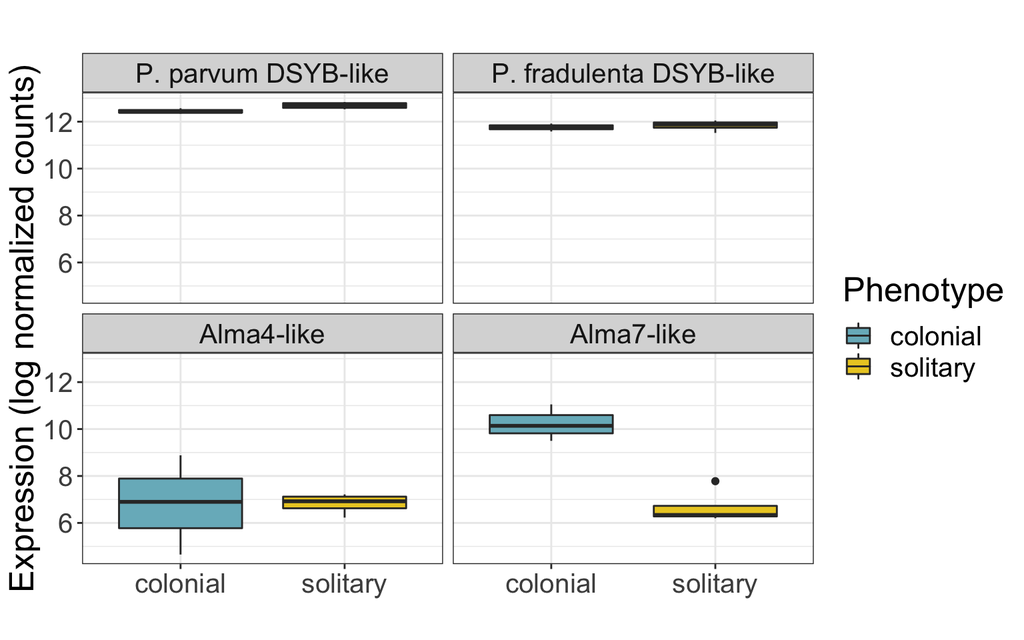

```r
pal<-wes_palette(name = "Zissou1", type="discrete")
colors<- c(pal[2],pal[3])

DSYBalma1<- ggplot(tcounts, aes(phenotype, expression, fill=phenotype)) +
  geom_boxplot() +
  facet_wrap(~annots_f, scales="fixed") +
  labs(x="",
       y="Expression (log normalized counts)",
       fill="Phenotype",
       title="") + theme_bw() + scale_fill_manual(values= colors) + theme(text = element_text(size=19))

DSYBalma1
```

```r
#ggsave("DSYBalma1.pdf", width = 8, height = 5, units = "in")
```

# 5 Pfam / GO Annotation

convert DE results to a data frame

```r
DEres <- as.data.frame(res)
DEres$trinity <- row.names(DEres)
sigDEgenes <- subset(DEres, padj < 0.05)
sigDEgenes$trinity <- row.names(sigDEgenes)
```

Import Pfam annotation results from dammit and fix pfam annotation formatting to match that used in the pfam2go mapping file

```r
pfamannot<- read.csv("./../Dibsi.Dammit/longestIsos_pg_euk_seqs.fasta.dammit/pfam.csv", header = TRUE)
pfamannot <- pfamannot[,-1]
pfamannot$Dbxref <- stri_sub(pfamannot$Dbxref , from = 2, to = -2)
pfamannot$Pfam <- gsub("\\..*","", pfamannot$Dbxref)
```

Import and format trinity ID to dammit transcript ID mapping file

```r
trinity2dammit <- read.csv("./../Dibsi.Dammit/longestIsos_pg_euk_seqs.fasta.dammit/longestIsos_pg_euk_seqs.fasta.dammit.namemap.csv", header = TRUE)
trinity2dammit1 <- trinity2dammit %>%
  separate(original, c("trinity"), sep = " ")
names(trinity2dammit1) <- c("trinity", "seqid")
```

Import and format pfam2go mapping file (downloaded from GO consortium)

```r
pfam2go <- read.delim("./../Dibsi.Dammit/longestIsos_pg_euk_seqs.fasta.dammit/pfam2go4R.txt", header = FALSE)
pfam2go1 <- pfam2go %>%
  separate(V1, c('V1_1', 'V1_2'), sep = '>') %>%
  separate(V1_1, c("Pfam", "name"), sep = " ") %>%
  separate(V1_2, c("GO_desc", "GO"), sep = ";")
pfam2go1$GO <-stri_sub(pfam2go1$GO, from = 2)
```

Create transcript to GO reference

```r
pfam1 <- merge(pfamannot, pfam2go1, by = "Pfam")
pfam2<- merge(pfam1, trinity2dammit1, by ="seqid" )
pfam3 <- merge(pfam2, sigDEgenes, by = "trinity")

pfamUP <- pfam3[pfam3$log2FoldChange >0 & pfam3$padj <0.05,]

pfam4<-merge(pfamannot, trinity2dammit1, by = "seqid")
pfam5<-merge(pfam4, sigDEgenes, by = "trinity")
```

Create list of all upregulated GO terms

```r
#write.table(data.frame(pfamUP$GO), file = "UPgo.txt", quote = FALSE, row.names=FALSE )
```

# 6 GO term enrichment testing with GOstats

format transcript to GO mapping for GOstats

```r
GOdf <- data.frame(pfam2$trinity, pfam2$GO)
GOdf$evidence <- "ISS"
names(GOdf) <- c("isoform", "GO", "evidence")
#reorder columns
GOdf <- GOdf[,c("GO","evidence","isoform")]
GOdf$GO <- as.character(GOdf$GO)
GOdf$isoform<- as.character(GOdf$isoform)
goframe=GOFrame(GOdf)
goAllFrame=GOAllFrame(goframe)
```

[output not shown]

```r
gsc <- GeneSetCollection(goAllFrame, setType = GOCollection())
```

prepare universe gene set, up-regulated gene set, and down-regulated gene set

```r
#make list of all genes
universe <-trinity2dammit1$trinity
#make list of upregulated genes
sigDEup <- sigDEgenes[sigDEgenes$log2FoldChange >0,]
uplist <- sigDEup$trinity
#make list of downregulated genes
sigDEdown<- sigDEgenes[sigDEgenes$log2FoldChange <0,]
downlist <- sigDEdown$trinity
```

## 6.1 GOterm enrichment in up-regulated genes

```r
upregulated = hyperGTest(
  GSEAGOHyperGParams(name = "Phaeo Colonies Upregged",
                     geneSetCollection=gsc,geneIds = uplist,
                     universeGeneIds=universe,ontology = "BP",pvalueCutoff = 0.05,conditional = FALSE,testDirection = "over"))

upregulated
```

```
## Gene to GO BP  test for over-representation
## 198 GO BP ids tested (20 have p < 0.05)
## Selected gene set size: 63
##     Gene universe size: 5276
##     Annotation package: Based on a GeneSetCollection Object
```

```r
htmlReport(upregulated, file="enrichedUPgostats.html")
upgoterms <-data.frame(summary(upregulated))
write.csv(upgoterms,"upgo.csv")
```

## 6.2 GOterm enrichment in down-reguated genes

```r
downregulated = hyperGTest(
  GSEAGOHyperGParams(name = "Phaeo Colonies DownRegged",
                     geneSetCollection=gsc,geneIds = downlist,
                     universeGeneIds=universe,ontology = "BP",pvalueCutoff = 0.05,conditional = FALSE,testDirection = "over"))

downregulated
```

```
## Gene to GO BP  test for over-representation
## 1106 GO BP ids tested (48 have p < 0.05)
## Selected gene set size: 1652
##     Gene universe size: 5276
##     Annotation package: Based on a GeneSetCollection Object
```

```r
htmlReport(downregulated, file = "enrichedDOWNdostats.html")
downgoterms <- data.frame(summary(downregulated))
write.csv(downgoterms,"downgo.csv")
```

## 6.3 GO term Figure (Revigo)

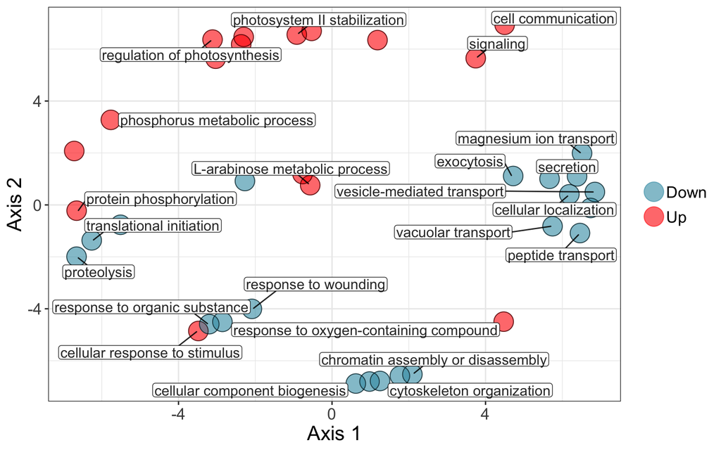

```r
revigo.names <- c("term_ID","description","frequency_%","plot_X","plot_Y","plot_size","value","uniqueness","dispensability");
revigo.data <- rbind(c("GO:0009611","response to wounding", 0.127,-2.088,-4.004, 4.212, 0.0000,0.897,0.000),
                     c("GO:0019646","aerobic electron transport chain", 0.042, 1.185, 6.346, 3.726, 1.0000,0.835,0.000),
                     c("GO:0023052","signaling", 6.765, 3.744, 5.649, 5.939, 1.0000,0.960,0.000),
                     c("GO:0051641","cellular localization", 2.041, 6.184, 0.408, 5.418, 0.0000,0.810,0.000),
                     c("GO:0065007","biological regulation",20.498, 4.473,-4.496, 6.420, 1.0000,0.966,0.000),
                     c("GO:0071824","protein-DNA complex subunit organization", 0.238, 1.769,-6.584, 4.485, 0.0000,0.804,0.000),
                     c("GO:0006487","protein N-linked glycosylation", 0.076,-5.511,-0.765, 3.992, 0.0000,0.848,0.025),
                     c("GO:0010109","regulation of photosynthesis", 0.008,-3.113, 6.366, 2.992, 1.0000,0.821,0.034),
                     c("GO:0006468","protein phosphorylation", 4.137,-6.655,-0.222, 5.725, 1.0000,0.826,0.054),
                     c("GO:0051716","cellular response to stimulus", 9.561,-3.483,-4.855, 6.089, 1.0000,0.831,0.059),
                     c("GO:0007154","cell communication", 7.219, 4.498, 6.936, 5.967, 1.0000,0.916,0.065),
                     c("GO:0019321","pentose metabolic process", 0.131,-0.768, 1.188, 4.227, 1.0000,0.857,0.109),
                     c("GO:0006793","phosphorus metabolic process",13.507,-5.763, 3.275, 6.239, 1.0000,0.893,0.115),
                     c("GO:0007034","vacuolar transport", 0.133, 5.746,-0.821, 4.231, 0.0000,0.837,0.262),
                     c("GO:0006413","translational initiation", 0.518,-6.262,-1.365, 4.823, 0.0000,0.860,0.268),
                     c("GO:0015833","peptide transport", 0.298, 6.461,-1.084, 4.582, 0.0000,0.818,0.283),
                     c("GO:0072511","divalent inorganic cation transport", 0.393, 6.739,-0.117, 4.702, 0.0000,0.814,0.292),
                     c("GO:0046903","secretion", 0.810, 5.668, 1.006, 5.017, 0.0000,0.779,0.316),
                     c("GO:0031323","regulation of cellular metabolic process",11.662,-3.033, 5.629, 6.175, 1.0000,0.757,0.322),
                     c("GO:0010033","response to organic substance", 0.900,-3.199,-4.592, 5.062, 0.0000,0.873,0.324),
                     c("GO:0016192","vesicle-mediated transport", 1.085, 6.849, 0.498, 5.144, 0.0000,0.814,0.327),
                     c("GO:1901605","alpha-amino acid metabolic process", 3.625,-2.270, 0.920, 5.668, 0.0000,0.823,0.329),
                     c("GO:0006508","proteolysis", 5.223,-6.657,-1.994, 5.826, 0.0000,0.897,0.335),
                     c("GO:0045184","establishment of protein localization", 2.407, 6.385, 1.099, 5.490, 0.0000,0.764,0.361),
                     c("GO:0043467","regulation of generation of precursor metabolites and energy", 0.030,-0.531, 6.701, 3.578, 1.0000,0.812,0.486),
                     c("GO:0044085","cellular component biogenesis", 4.355, 0.620,-6.879, 5.747, 0.0000,0.833,0.490),
                     c("GO:0006887","exocytosis", 0.210, 4.720, 1.113, 4.430, 0.0000,0.754,0.492),
                     c("GO:0015693","magnesium ion transport", 0.086, 6.515, 1.992, 4.044, 0.0000,0.829,0.527),
                     c("GO:0007010","cytoskeleton organization", 0.786, 1.251,-6.780, 5.004, 0.0000,0.805,0.563),
                     c("GO:0006333","chromatin assembly or disassembly", 0.120, 2.094,-6.525, 4.188, 0.0000,0.804,0.572),
                     c("GO:0006323","DNA packaging", 0.227, 0.977,-6.802, 4.465, 0.0000,0.811,0.587),
                     c("GO:0019222","regulation of metabolic process",11.942,-2.367, 6.182, 6.185, 1.0000,0.811,0.619),
                     c("GO:0042549","photosystem II stabilization", 0.005,-0.918, 6.559, 2.814, 1.0000,0.787,0.650),
                     c("GO:0006796","phosphate-containing compound metabolic process",13.110,-6.717, 2.076, 6.226, 1.0000,0.870,0.664),
                     c("GO:0046373","L-arabinose metabolic process", 0.044,-0.569, 0.759, 3.752, 1.0000,0.853,0.664),
                     c("GO:1901700","response to oxygen-containing compound", 0.503,-2.856,-4.504, 4.810, 0.0000,0.877,0.675),
                     c("GO:0050794","regulation of cellular process",18.840,-2.302, 6.469, 6.383, 1.0000,0.777,0.698));

one.data <- data.frame(revigo.data);
names(one.data) <- revigo.names;
one.data <- one.data [(one.data$plot_X != "null" & one.data$plot_Y != "null"), ];
one.data$plot_X <- as.numeric( as.character(one.data$plot_X) );
one.data$plot_Y <- as.numeric( as.character(one.data$plot_Y) );
one.data$plot_size <- as.numeric( as.character(one.data$plot_size) );
one.data$frequency <- as.numeric( as.character(one.data$frequency) );
one.data$uniqueness <- as.numeric( as.character(one.data$uniqueness) );
one.data$dispensability <- as.numeric( as.character(one.data$dispensability) )

ex <- one.data [ c(1,3,4,8,9,10,11,13:16,18,20,21,23, 26:30,  33,35,36), ];

reviGOplot <- ggplot( data = one.data ) +
  geom_point( aes( plot_X, plot_Y, colour = value), alpha = I(0.6), size =7) +
  scale_colour_manual(values =c("#3B9AB2", "red"), labels= c("Down", "Up")) +
  geom_point( aes(plot_X, plot_Y), shape = 21, fill = "transparent", colour = I (alpha ("black", 0.6) ), size = 7) +   scale_size_area() + scale_size( range=c(5, 30)) + theme_bw() +
  geom_label_repel(data = ex, aes(plot_X, plot_Y, label = description), colour = I(alpha("black", 0.85)), size = 4, nudge_x = 0 , point.padding = 0.2, label.padding = 0.1)+ labs (y = "Axis 2", x = "Axis 1") +
  theme(legend.key = element_blank()) + theme(text = element_text(size=16)) + theme(legend.title=element_blank())

reviGOplot
```

save:

```r
ggsave("reviGOplot.pdf",  width = 8, height = 5, units = "in")
```

### 6.3.1 Shiny Version

To view interactive version, click [here](https://brisbin.shinyapps.io/shinycolsol/).

# 7 KEGG Pathway Annotation

convert DeSeq results to data frame:

```r
resDFa<- as.data.frame(res)
dim(resDFa)
```

```
## [1] 43301     6
```

filter for significant genes:

```r
resDF <- subset(resDFa, padj < 0.05)
dim(resDF)
```

```
## [1] 7769    6
```

Import KO data:

```r
ko<- read.csv('user_ko.csv', header = TRUE)
ko$Phaeo1528_GeneID<-gsub("\\|.*","",as.character(ko$Phaeo1528_GeneID))
ko<- ko[ko$KO != "",]
length(ko)
```

```
## [1] 2
```

How many are unique?

```r
length(unique(ko$Phaeo1528_GeneID))
```

```
## [1] 9967
```

Merge KO data with significant Deseq2 results

```r
resDF$Phaeo1528_GeneID <- row.names(resDF)
resDF<-merge(ko, resDF, by = 'Phaeo1528_GeneID')
dim(resDF)
```

```
## [1] 3622    8
```

How many are unique?

```r
length(unique(resDF$Phaeo1528_GeneID))
```

```
## [1] 3305
```

Make Data Frame with all annotated genes:

```r
resALL<- as.data.frame(res)
resALL$Phaeo1528_GeneID <- row.names(resALL)
resALL<-merge(ko, resALL, by = 'Phaeo1528_GeneID')
dim(resALL)
```

```
## [1] 9216    8
```

Get universe paths:

```r
koslist<- resALL$KO
paths <- character(length=0)
for(i in 1:length(koslist)) {
  pathway <- system(paste0("curl http://rest.kegg.jp/link/pathway/", koslist[[i]]), intern=TRUE)
  if (pathway[[1]] == "") {
    paths[[i]]<- "NA"
  } else if (length(pathway) == 1) {
    paths[[i]] <- stri_sub(pathway[[1]], 16)
  } else {
    l <- length(pathway)
    paths[[i]] <- stri_sub(pathway[[2]], 16)
  }
}
resALL$path<-paths
```

remove lines with pathway = NA

```r
resALLnoNA <- resALL[resALL$path != "NA",]
resALLnoNA <- resALLnoNA[resALLnoNA$path !='PUBLIC "-//W3C//DTD XHTML 1.0 Strict//EN"',]
dim(resALLnoNA)
```

```
## [1] 5593    9
```

how many unique pathways?

```r
length(unique(resALL$path))
```

```
## [1] 285
```

save results

```r
#write.csv(resALL, file = "results.csv", row.names= FALSE )
```

# 8 Kegg Enrichment

## 8.1 Hypergeometric Test with Cluster Profiler

### 8.1.1 CP enrichment in upregulated Genes

```r
gene.data <- resALL[!duplicated(resALL$Phaeo1528_GeneID), ]
row.names(gene.data) <- gene.data[[1]]
de.genes <- subset(gene.data, padj < 0.05)
up.genes <-subset(de.genes, log2FoldChange > 1)
up.genes.names <- row.names(up.genes)

resALLnoNA <- resALL[resALL$path != "NA",]
resALLnoNA <- resALLnoNA[resALLnoNA$path !='PUBLIC "-//W3C//DTD XHTML 1.0 Strict//EN"',]
dim(resALLnoNA)
```

```
## [1] 5593    9
```

```r
genepathways <- data.frame(resALLnoNA$path, resALLnoNA$Phaeo1528_GeneID)
names(genepathways)<-c("pathwayID", "geneID")
universelist<- genepathways$geneID
universe<-as.vector(universelist)
length(universe)
```

```
## [1] 5593
```

```r
ko_up<- resALLnoNA[resALLnoNA$log2FoldChange > 0 & resALLnoNA$padj <= 0.05 ,]
de<-ko_up$Phaeo1528_GeneID
de<- as.vector(de)

enrchd <- enricher(de, pvalueCutoff = 0.05, pAdjustMethod = "none", universe, TERM2GENE = genepathways )
upedf<- data.frame(enrchd)

kosup<- row.names(upedf)
name <- character(length=0)
class <- character(length=0)

for(i in 1:length(kosup)) {
  pathway <- system(paste0("curl http://rest.kegg.jp/get/", kosup[[i]]), intern=TRUE)
  name[[i]] <- pathway[[2]]
  class[[i]] <-pathway[[3]]
}

upedf$name <- name
upedf$class <- class

write.csv(upedf, file = "keggEnrichment_UP_HyperGeo.csv", row.names = FALSE)
```

### 8.1.2 CP enrichment in downregulated Genes

```r
ko_down<- resALLnoNA[resALLnoNA$log2FoldChange < 0 & resALLnoNA$padj <= 0.05 ,]
de<-ko_down$Phaeo1528_GeneID
de<- as.vector(de)

enrchd <- enricher(de, pvalueCutoff = 0.05, pAdjustMethod = "none", universe, TERM2GENE = genepathways )
downedf<- data.frame(enrchd)

kosup<- row.names(downedf)
name <- character(length=0)
class <- character(length=0)

for(i in 1:length(kosup)) {
  pathway <- system(paste0("curl http://rest.kegg.jp/get/", kosup[[i]]), intern=TRUE)
  name[[i]] <- pathway[[2]]
  class[[i]] <-pathway[[3]]
}

downedf$name <- name
downedf$class <- class

write.csv(downedf, file = "keggEnrichment_DOWN_HyperGeo.csv", row.names = FALSE)
```

## 8.2 Linear Model Analysis with edgeR

make universe (list of all genes with KO)

```r
genepathways <- data.frame(resALLnoNA$Phaeo1528_GeneID, resALLnoNA$path)
names(genepathways)<-c("geneID", "pathwayID")
universelist<- genepathways$geneID
universelist<-as.vector(universelist)
length(universelist)
```

```
## [1] 5593
```

### 8.2.1 edgeR enrichment in Upregulated Genes:

```r
ko_up<- resALLnoNA[resALLnoNA$log2FoldChange > 0 & resALLnoNA$padj <= 0.05 ,]
de<-ko_up$Phaeo1528_GeneID
de<- as.vector(de)

keggUP<-kegga(de, universe = universelist, species = NULL, species.KEGG = NULL, convert = FALSE,
              gene.pathway = genepathways, pathway.names = NULL,
              prior.prob = NULL, covariate=NULL, plot=FALSE)

names(keggUP) <- c("Pathway", "N", "DE" , "p")
keggUP$Pathway<-row.names(keggUP)
```

Make dataframe of significantly enriched pathways:

```r
KeggUpsig<- keggUP[keggUP$p < 0.05,]
```

get descriptions of significantly enriched upregulated pathways:

```r
kosup<- row.names(KeggUpsig)
name <- character(length=0)
class <- character(length=0)

for(i in 1:length(kosup)) {
  pathway <- system(paste0("curl http://rest.kegg.jp/get/", kosup[[i]]), intern=TRUE)
  name[[i]] <- pathway[[2]]
  class[[i]] <-pathway[[3]]
}

KeggUpsig$name <- name
KeggUpsig$class <- class
```

```r
KeggUpsig[,1:5]
```

```
##         Pathway  N DE           p
## ko04151 ko04151 47  3 0.016094461
## ko00601 ko00601  3  1 0.033879684
## ko04022 ko04022 23  3 0.002133689
## ko04626 ko04626 24  2 0.030142024
## ko04216 ko04216  3  1 0.033879684
## ko04712 ko04712  4  2 0.000758662
## ko05203 ko05203  2  1 0.022713838
##                                                                           name
## ko04151                                 NAME        PI3K-Akt signaling pathway
## ko00601 NAME        Glycosphingolipid biosynthesis - lacto and neolacto series
## ko04022                                 NAME        cGMP-PKG signaling pathway
## ko04626                                 NAME        Plant-pathogen interaction
## ko04216                                                NAME        Ferroptosis
## ko04712                                   NAME        Circadian rhythm - plant
## ko05203                                       NAME        Viral carcinogenesis
```

save results:

```r
write.csv(KeggUpsig, file = "keggEnrichment_UP_n.csv", row.names = FALSE)
```

*Get descriptions of all pathways available for significantly upregulated gene*

Make dataframe of upregulated pathways without duplicated entries:

```r
KeggUpE<- keggUP[keggUP$DE != 0,]
```

how many?

```r
dim(KeggUpE)
```

```
## [1] 42  4
```

```r
kosup<- row.names(KeggUpE)
name <- character(length=0)
class <- character(length=0)

for(i in 1:length(kosup)) {
  pathway <- system(paste0("curl http://rest.kegg.jp/get/", kosup[[i]]), intern=TRUE)
  name[[i]] <- pathway[[2]]
  class[[i]] <-pathway[[3]]
}

KeggUpE$name <- name
KeggUpE$class <- class
```

save:

```r
write.csv(KeggUpE , file = "upregulated_pathways_nonredundant_n.csv" , row.names = FALSE )
```

### 8.2.2 edgeR enrichment in Downregulated Genes:

```r
ko_down<- resALLnoNA[resALLnoNA$log2FoldChange < 0 & resALLnoNA$padj <= 0.05 ,]
de<-ko_down$Phaeo1528_GeneID
de<- as.vector(de)

keggDOWN<-kegga(de, universe = universelist, species = NULL, species.KEGG = NULL, convert = FALSE,
              gene.pathway = genepathways, pathway.names = NULL,
              prior.prob = NULL, covariate=NULL, plot=FALSE)
```

```r
names(keggDOWN) <- c("Pathway", "N", "DE" , "p")
keggDOWN$Pathway<-row.names(keggDOWN)
KeggDOWNsig<- keggDOWN[keggDOWN$p < 0.05,]
dim(KeggDOWNsig)
```

```
## [1] 12  4
```

get descriptions of significantly enriched downregulated pathways:

```r
kosup<- row.names(KeggDOWNsig)
name <- character(length=0)
class <- character(length=0)

for(i in 1:length(kosup)) {
  pathway <- system(paste0("curl http://rest.kegg.jp/get/", kosup[[i]]), intern=TRUE)
  name[[i]] <- pathway[[2]]
  class[[i]] <-pathway[[3]]
}

KeggDOWNsig$name <- name
KeggDOWNsig$class <- class
```

```r
KeggDOWNsig[,1:5]
```

```
##         Pathway   N DE            p
## ko04141 ko04141 138 63 4.687649e-02
## ko04014 ko04014  50 27 1.757535e-02
## ko00190 ko00190  98 47 3.260171e-02
## ko04142 ko04142  69 44 1.561576e-05
## ko04016 ko04016  21 17 8.279295e-05
## ko01521 ko01521  49 32 1.163482e-04
## ko04152 ko04152  27 17 8.293888e-03
## ko00100 ko00100  23 14 2.393082e-02
## ko00600 ko00600  28 16 3.379579e-02
## ko04140 ko04140  37 25 2.962792e-04
## ko04742 ko04742   8  7 6.506882e-03
## ko00071 ko00071  28 16 3.379579e-02
##                                                            name
## ko04141 NAME        Protein processing in endoplasmic reticulum
## ko04014                       NAME        Ras signaling pathway
## ko00190                   NAME        Oxidative phosphorylation
## ko04142                                    NAME        Lysosome
## ko04016              NAME        MAPK signaling pathway - plant
## ko01521   NAME        EGFR tyrosine kinase inhibitor resistance
## ko04152                      NAME        AMPK signaling pathway
## ko00100                        NAME        Steroid biosynthesis
## ko00600                     NAME        Sphingolipid metabolism
## ko04140                          NAME        Autophagy - animal
## ko04742                          NAME        Taste transduction
## ko00071                      NAME        Fatty acid degradation
```

save:

```r
write.csv(KeggDOWNsig , file = "KeggDownsig.csv" , row.names = FALSE )
```